# ggplot2 Graphing Display

Kelsey Huntzberry

6/21/2019

setwd(“~/Documents/R_Class_Meetup/Class5/Results”)

```r
her.opioid <- read.csv("~/Documents/R_Class_Meetup/Class5/Data/state_overdoses_heroin_opioids.csv", stringsAsFactors = F)

county.pres <- read.csv("~/Documents/R_Class_Meetup/Class5/Data/county_prescribing_rates_data.csv", stringsAsFactors = F)

state.pres <- read.csv("~/Documents/R_Class_Meetup/Class5/Data/state_prescribe_overdose_data.csv", stringsAsFactors = F)

library(ggplot2)
library(ggrepel)
```

# Create summary data and basic line graph

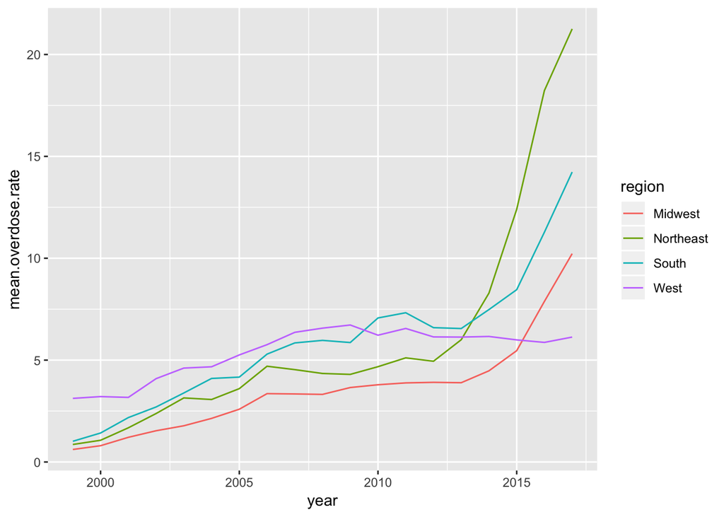

```r
# Create summarized graphing data
opioid.only <- subset(her.opioid, drug == "Opioid Analgesic")

opioid.year.region <- aggregate(opioid.only$overdose.rate,
                                by = list(opioid.only$region, opioid.only$year),
                                FUN = mean, na.rm = TRUE)

colnames(opioid.year.region) <- c("region", "year", "mean.overdose.rate")

# Create basic line graph
opioid.od.line <- ggplot(data = opioid.year.region,
                         aes(x = year, y = mean.overdose.rate, color = region)) +
  geom_line()

opioid.od.line
```

# Add graph titles and labels, setting figure size, increasing width of lines

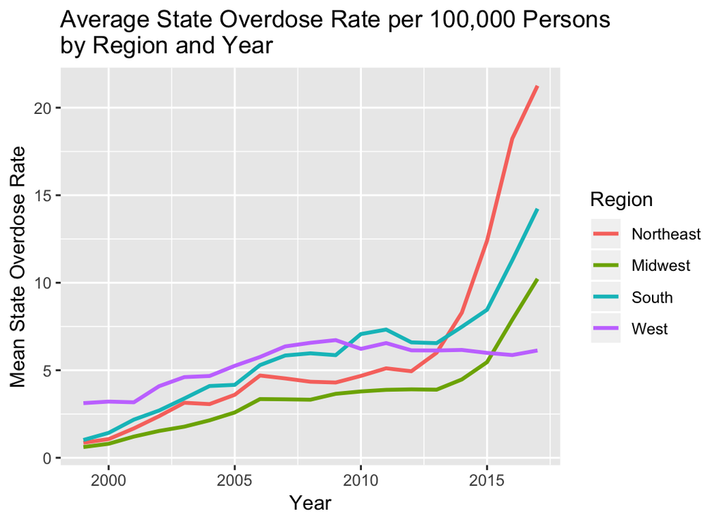

```r
## I would like my regions listed as Northeast, Midwest, South, and West because this makes sense more logically
## To do this, you need to make it a factor variable and specify levels
opioid.year.region$region <- factor(opioid.year.region$region,
                                    levels = c("Northeast", "Midwest", "South", "West"))

opioid.od.line <- ggplot(data = opioid.year.region,
                         aes(x = year, y = mean.overdose.rate, color = region)) +
                  geom_line(size = 1) +
                  labs(title = "Average State Overdose Rate per 100,000 Persons\nby Region and Year",
                     color = "Region",
                     x = "Year",
                     y = "Mean State Overdose Rate")

opioid.od.line
```

# Add plot theme (getting rid of default gray background) and line changing colors

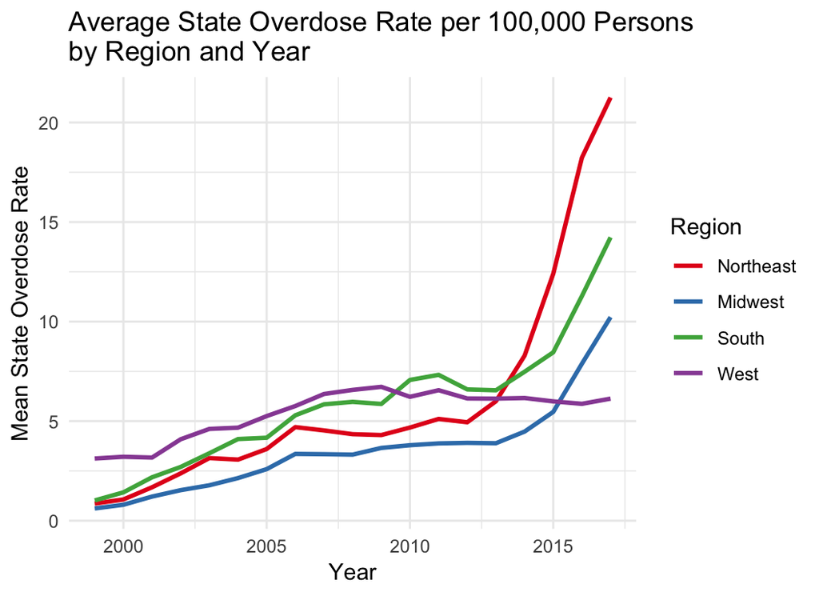

```r
opioid.od.line <- ggplot(data = opioid.year.region,
                         aes(x = year, y = mean.overdose.rate, color = region)) +
  geom_line(size = 1) +
  labs(title = "Average State Overdose Rate per 100,000 Persons\nby Region and Year",
     color = "Region",
     x = "Year",
     y = "Mean State Overdose Rate") +
  theme_minimal() +
  scale_color_brewer(palette = "Set1")


opioid.od.line
```

# Adding points to my plot lines

# Formatting all graph text and legend position

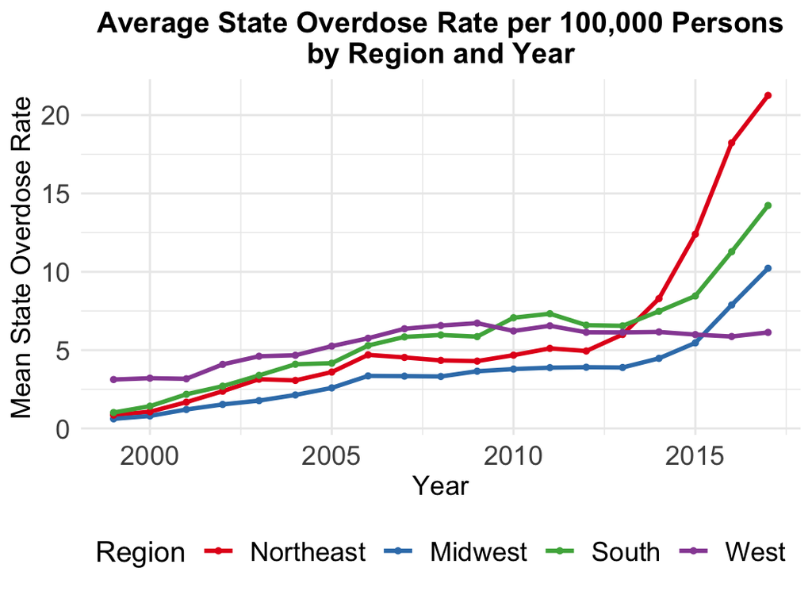

```r
opioid.od.line <- ggplot(data = opioid.year.region,
                         aes(x = year, y = mean.overdose.rate, color = region)) +
  geom_line(size = 1) +
  geom_point(size = 1) +
  labs(title = "Average State Overdose Rate per 100,000 Persons\nby Region and Year",
     color = "Region",
     x = "Year",
     y = "Mean State Overdose Rate") +
  theme_minimal() +
  scale_color_brewer(palette = "Set1") +
  theme(plot.title = element_text(size = 14, hjust = 0.5, face = "bold"),
        axis.title = element_text(size = 13),
        axis.text = element_text(size = 13),
        legend.title = element_text(size = 14, hjust = 0.5),
        legend.text = element_text(size = 13),
        legend.position = "bottom")

opioid.od.line
```

# Start a new graph showing current average opioid prescribing by rural.metro and region

# Create summarized data and create basic plot

```r
table(county.pres$year)
```

```
##
## 2006 2007 2008 2009 2010 2011 2012 2013 2014 2015 2016 2017
## 2754 2746 2758 2750 2741 2745 2736 2753 2960 2963 2962 2955
```

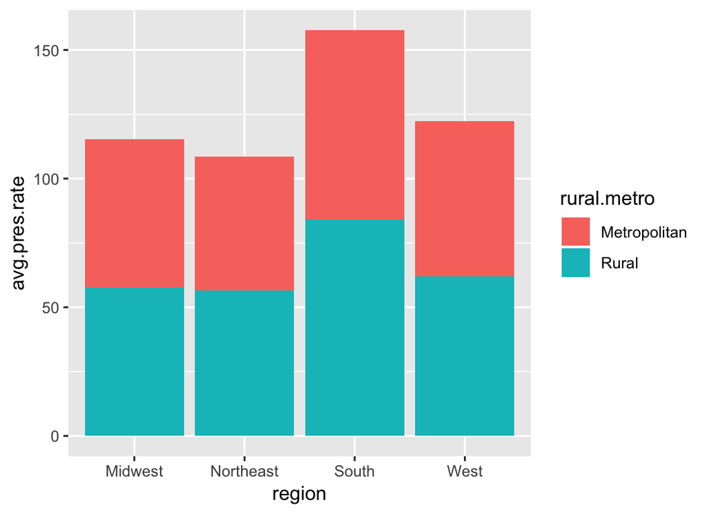

```r
# Most current year is 2017

prescribe.2017 <- subset(county.pres, year == 2017)

avg.pres.rururb.region <- aggregate(prescribe.2017$prescribing.rate,
                                    by = list(prescribe.2017$rural.metro, prescribe.2017$region),
                                    FUN = mean, na.rm = TRUE)

colnames(avg.pres.rururb.region) <- c("rural.metro", "region", "avg.pres.rate")

pres.bar.rururb <- ggplot(data = avg.pres.rururb.region,
                            aes(x = region, y = avg.pres.rate, fill = rural.metro)) +
  geom_bar(stat = "identity")

pres.bar.rururb
```

# In this case it makes no sense to do a stacked bar graph with aggregate bars

# Changing this to a grouped bar graph

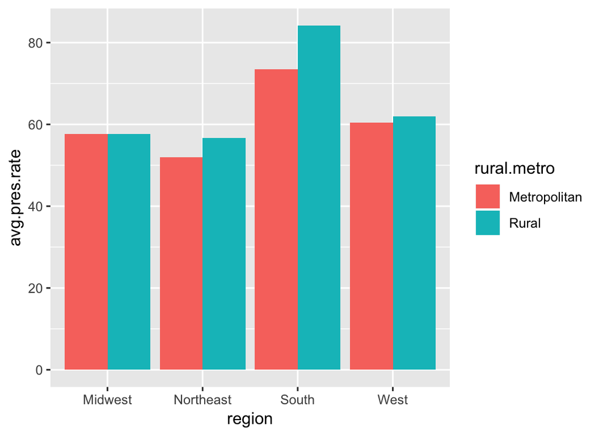

```r
pres.bar.rururb <- ggplot(data = avg.pres.rururb.region,
                            aes(x = region, y = avg.pres.rate, fill = rural.metro)) +
  geom_bar(stat = "identity", position = position_dodge())

pres.bar.rururb
```

# I want to change my theme and manually change my bar colors

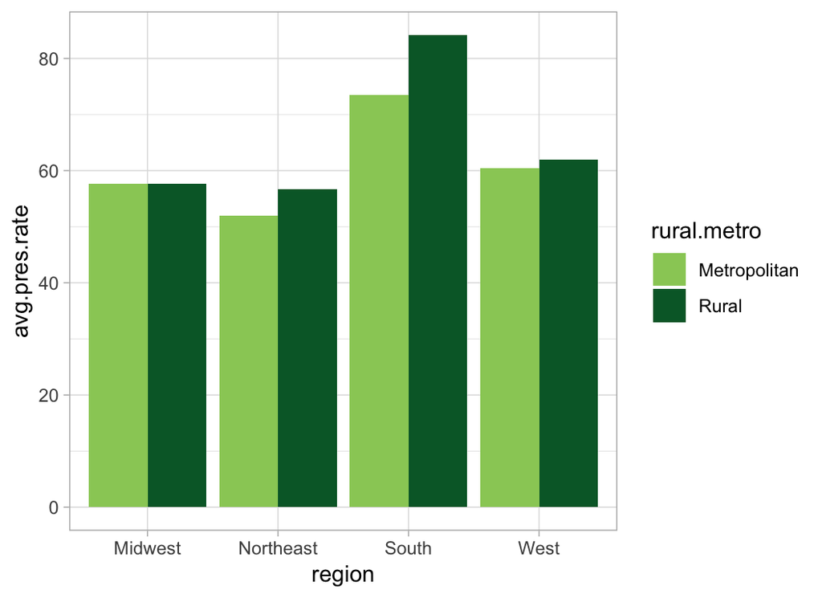

```r
pres.bar.rururb <- ggplot(data = avg.pres.rururb.region,
                            aes(x = region, y = avg.pres.rate, fill = rural.metro)) +
  geom_bar(stat = "identity", position = position_dodge()) +
  theme_light() +
  scale_fill_manual(values = c("#99CC66", "#006633"))

pres.bar.rururb
```

# Adding labels

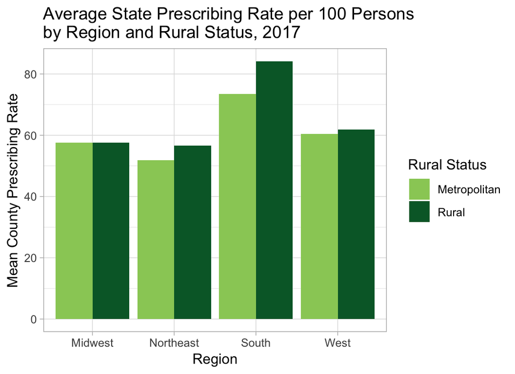

```r
pres.bar.rururb <- ggplot(data = avg.pres.rururb.region,
                            aes(x = region, y = avg.pres.rate, fill = rural.metro)) +
  geom_bar(stat = "identity", position = position_dodge()) +
  theme_light() +
  scale_fill_manual(values = c("#99CC66", "#006633")) +
  labs(title = "Average State Prescribing Rate per 100 Persons\nby Region and Rural Status, 2017",
       fill = "Rural Status",
       x = "Region",
       y = "Mean County Prescribing Rate")

pres.bar.rururb
```

# Increase label size, color, and format legend

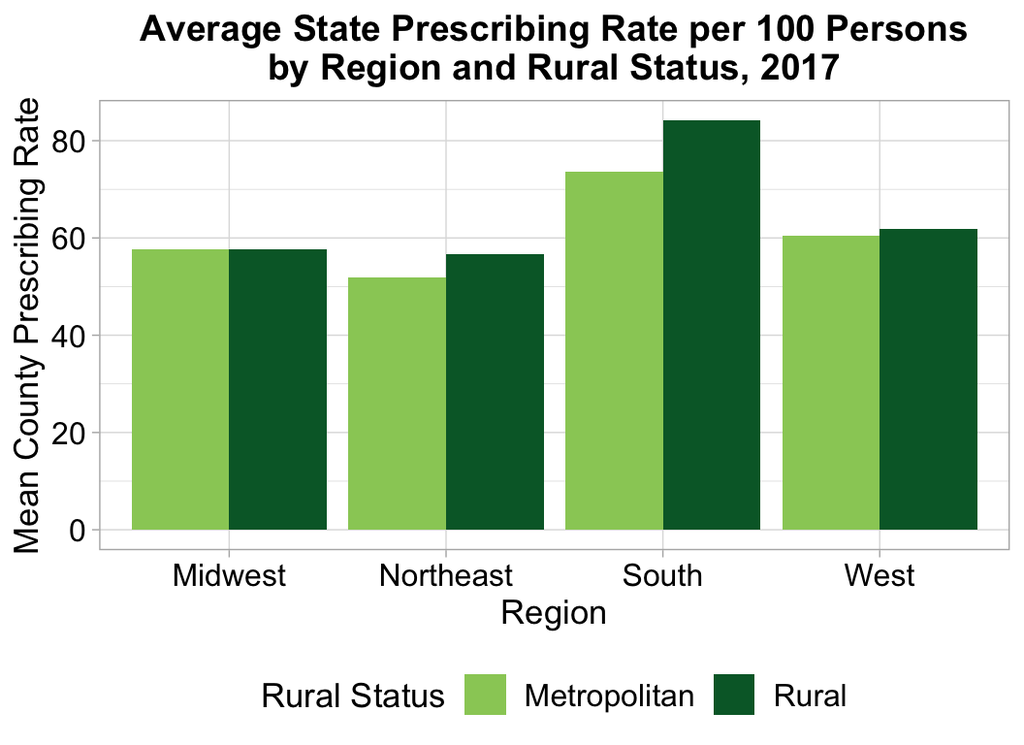

```r
pres.bar.rururb <- ggplot(data = avg.pres.rururb.region,
                            aes(x = region, y = avg.pres.rate, fill = rural.metro)) +
  geom_bar(stat = "identity", position = position_dodge()) +
  theme_light() +
  scale_fill_manual(values = c("#99CC66", "#006633")) +
  labs(title = "Average State Prescribing Rate per 100 Persons\nby Region and Rural Status, 2017",
       fill = "Rural Status",
       x = "Region",
       y = "Mean County Prescribing Rate") +
  theme(plot.title = element_text(size = 14, hjust = 0.5, face = "bold"),
        axis.title = element_text(size = 13),
        axis.text = element_text(size = 12, color = "black"),
        legend.title = element_text(size = 13),
        legend.text = element_text(size = 12),
        legend.position = "bottom")

pres.bar.rururb
```

# Order bars by magnitude greatest to smallest

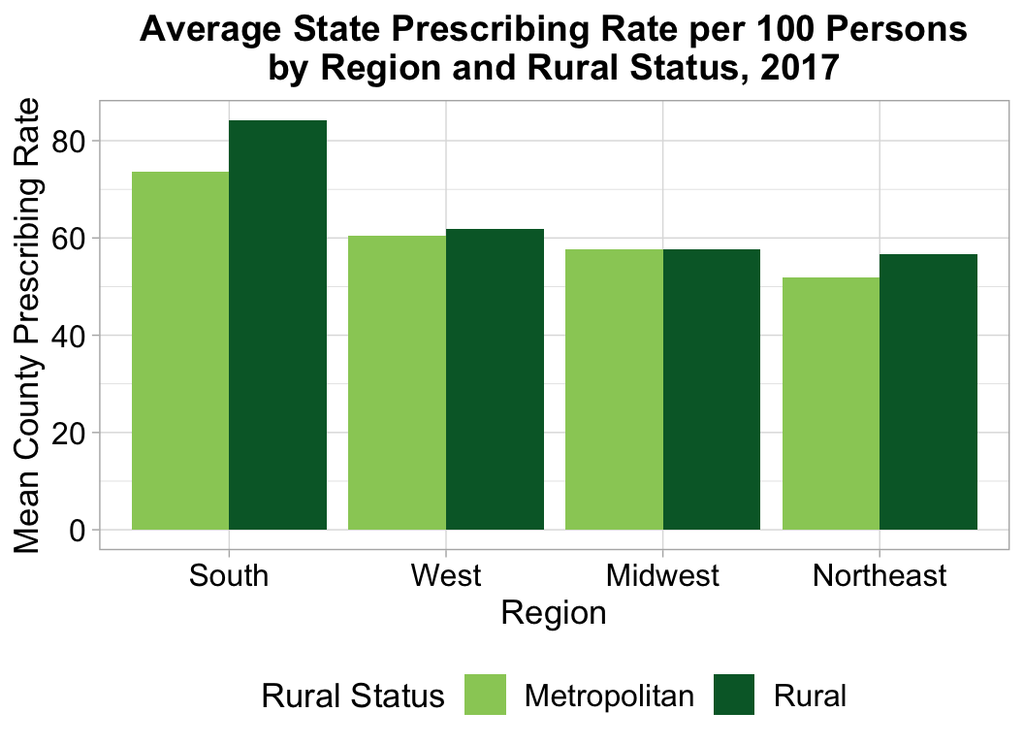

```r
avg.pres.rururb.region$region <- factor(avg.pres.rururb.region$region,
                                        levels = c("South", "West", "Midwest", "Northeast"))

pres.bar.rururb <- ggplot(data = avg.pres.rururb.region,
                            aes(x = region, y = avg.pres.rate, fill = rural.metro)) +
  geom_bar(stat = "identity", position = position_dodge()) +
  theme_light() +
  scale_fill_manual(values = c("#99CC66", "#006633")) +
  labs(title = "Average State Prescribing Rate per 100 Persons\nby Region and Rural Status, 2017",
       fill = "Rural Status",
       x = "Region",
       y = "Mean County Prescribing Rate") +
  theme(plot.title = element_text(size = 14, hjust = 0.5, face = "bold"),
        axis.title = element_text(size = 13),
        axis.text = element_text(size = 12, color = "black"),
        legend.title = element_text(size = 13),
        legend.text = element_text(size = 12),
        legend.position = "bottom")

pres.bar.rururb
```

# Start with new graph graphing prescribing rates by overdose rates with new state_prescribe_overdose_data.csv

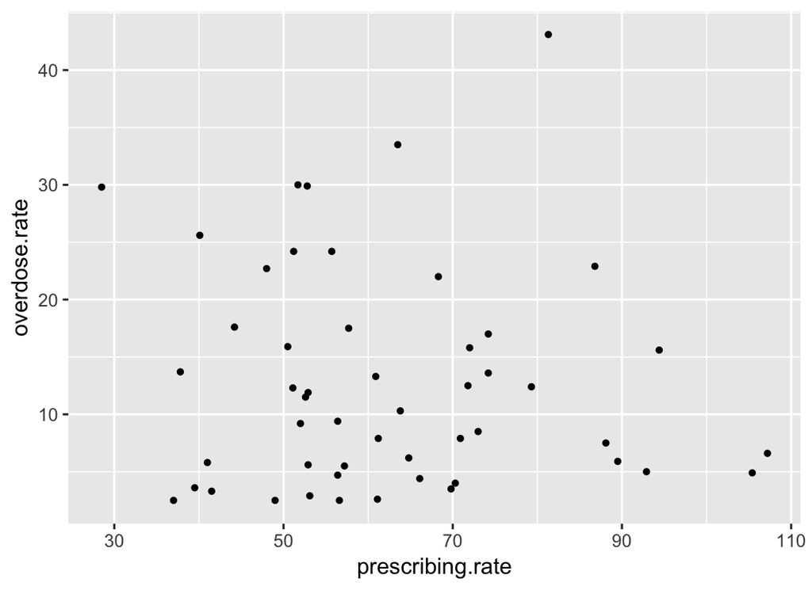

```r
# Subset data to just 2017 data
state.pres.2017 <-subset(state.pres, year == 2017)

pres.od.scatter <- ggplot(data = state.pres.2017,
                            aes(x = prescribing.rate, y = overdose.rate)) +
  geom_point(size = 1, color = "black")

pres.od.scatter
```

# Add a regression line to show the average trend or relationship between the two variables

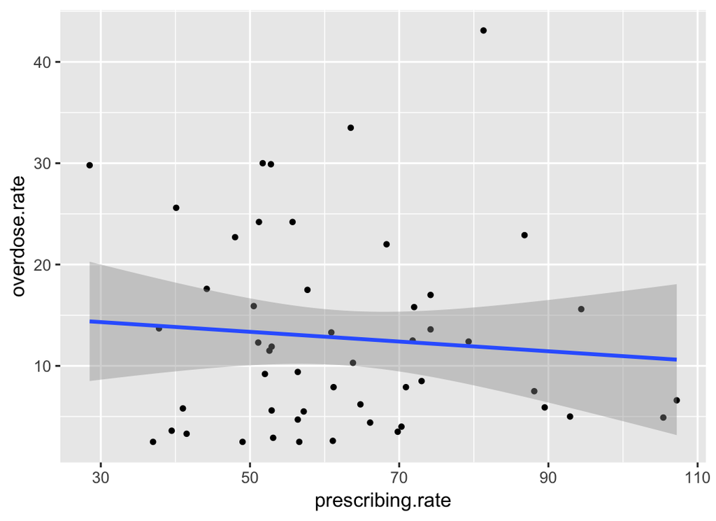

```r
# Subset data to just 2017 data
state.pres.2017 <-subset(state.pres, year == 2017)

pres.od.scatter <- ggplot(data = state.pres.2017,
                            aes(x = prescribing.rate, y = overdose.rate)) +
  geom_point(size = 1, color = "black") +
  geom_smooth(method = lm)

pres.od.scatter
```

# I want to remove the confidence bands from the regression line, change its color, and change the theme to remove grey background

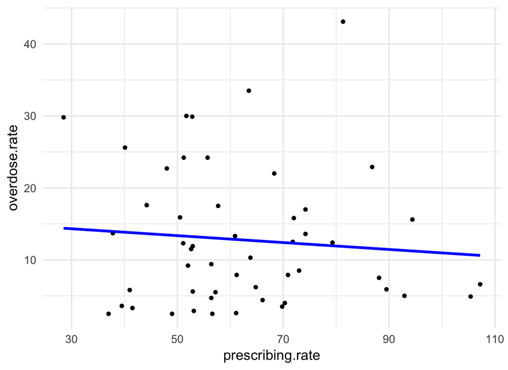

```r
# Subset data to just 2017 data
state.pres.2017 <-subset(state.pres, year == 2017)

pres.od.scatter <- ggplot(data = state.pres.2017,
                            aes(x = prescribing.rate, y = overdose.rate)) +
  geom_point(size = 1, color = "black") +
  geom_smooth(method = lm, se = FALSE, color = "blue") +
  theme_minimal()

pres.od.scatter
```

# Add labels

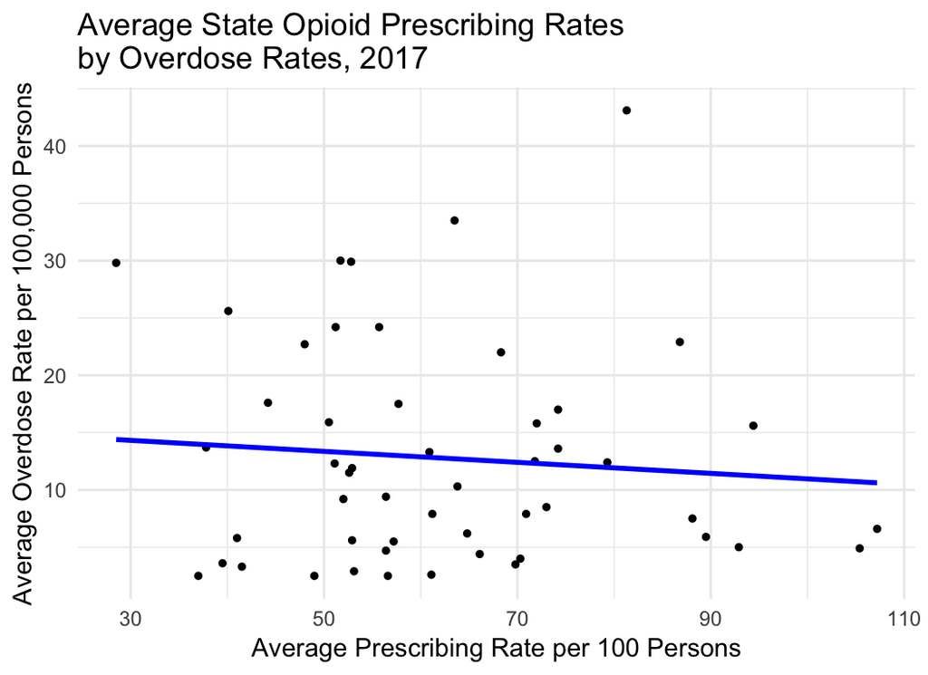

```r
# Subset data to just 2017 data
state.pres.2017 <-subset(state.pres, year == 2017)

pres.od.scatter <- ggplot(data = state.pres.2017,
                            aes(x = prescribing.rate, y = overdose.rate)) +
  geom_point(size = 1, color = "black") +
  geom_smooth(method = lm, se = FALSE, color = "blue") +
  theme_minimal() +
  labs(title = "Average State Opioid Prescribing Rates\nby Overdose Rates, 2017",
     x = "Average Prescribing Rate per 100 Persons",
     y = "Average Overdose Rate per 100,000 Persons")

pres.od.scatter
```

# Change formatting titles and axis labels

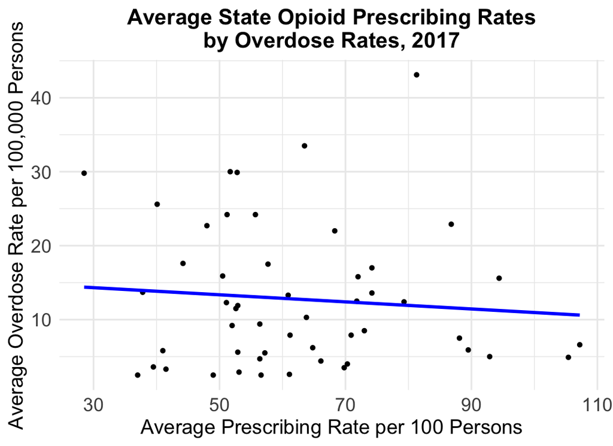

```r
# Subset data to just 2017 data
pres.od.scatter <- ggplot(data = state.pres.2017,
                            aes(x = prescribing.rate, y = overdose.rate)) +
  geom_point(size = 1, color = "black") +
  geom_smooth(method = lm, se = FALSE, color = "blue") +
  theme_minimal() +
  labs(title = "Average State Opioid Prescribing Rates\nby Overdose Rates, 2017",
     x = "Average Prescribing Rate per 100 Persons",
     y = "Average Overdose Rate per 100,000 Persons") +
    theme(plot.title = element_text(size = 14, hjust = 0.5, face = "bold"),
        axis.title = element_text(size = 13),
        axis.text = element_text(size = 12))

pres.od.scatter
```

# X-axis is getting cut off, want to change the scale limits and breaks so the x-axis makes more sense and is more readable

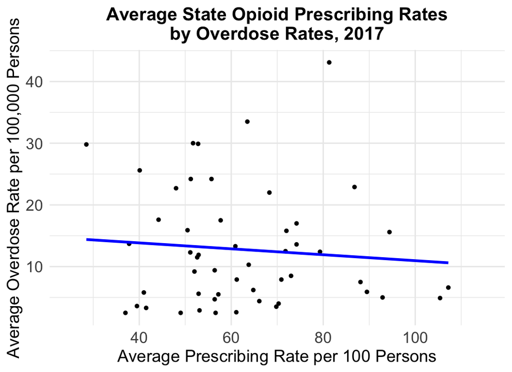

```r
# Subset data to just 2017 data
pres.od.scatter <- ggplot(data = state.pres.2017,
                            aes(x = prescribing.rate, y = overdose.rate)) +
  geom_point(size = 1, color = "black") +
  geom_smooth(method = lm, se = FALSE, color = "blue") +
  theme_minimal() +
  labs(title = "Average State Opioid Prescribing Rates\nby Overdose Rates, 2017",
     x = "Average Prescribing Rate per 100 Persons",
     y = "Average Overdose Rate per 100,000 Persons") +
    theme(plot.title = element_text(size = 14, hjust = 0.5, face = "bold"),
        axis.title = element_text(size = 13),
        axis.text = element_text(size = 12)) +
  scale_x_continuous(limits = c(25, 115), breaks = c(40, 60, 80, 100))

pres.od.scatter
```